# STAT340 HW05: Multiple testing, bootstrap

Kara Conrad

5/8/2022

## Problem 1 (15 pts)

Suppose we test $m$ null hypotheses, all of which are true. We control the Type I error for each null hypothesis at level $\alpha$. For each sub-problem, justify your answer.

1. In total, how many Type I errors do we expect to make? The rate of type I errors is alpha for each hypotheses. So, in this case the number of type I errors would be m times alpha.
2. Suppose that the $m$ tests that we perform are independent. What is the family-wise error rate associated with these $m$ tests? Hint: If two events $A$ and $B$ are independent, then $\operatorname{Pr}(A \cap B)=$ $\operatorname{Pr} A. \operatorname{Pr}(B)$. The family-wise error rate is the probability that out of m events, at least one is error. So P(error >= 1) = 1 - P(error = 0) = 1-(1-a)^m.
3. Suppose that $m=2$, and that the $p$-values for the two tests are positively correlated, so that if one is small then the other will tend to be small as well, and if one is large then the other will tend to be large. How does the family-wise error rate associated with these $m=2$ tests qualitatively compare to b. with $m=2$?
   - *Hint: First, suppose that the two p-values are perfectly correlated.* If the p-values for these tests are positively correlated, then the family-wise error rate associated will decrease. This is since when they are highly correlated with each other, then it is less likely for there to be a false positive. In a case like this, we can either reject or fail to reject both null hypotheses.
4. Suppose again that $m=2$, but that now the $p$-values for the two tests are negatively correlated, so that if one is large then the other will tend to be small. How does the family-wise error rate associated with these $m=2$ tests qualitatively compare to the answer in b. with $m=2$?
   - *Hint: First, suppose that whenever one $p$-value is less than $\alpha$, then the other will be greater than $\alpha$. In other words, we can never reject both null hypotheses.* If the p-values for these tests are negatively correlated, then it would be the opposite outcome of part c. So the family-wise error rate associated will increase. Because the two p-values differ vastly in a negative correlation, this may lead us to reject one null hypothesis, and fail to reject the other. Thus, this would result in the family-wise error rate increasing.

## Problem 2 (20 pts)

In this problem, we will simulate data from $m=100$ fund managers.

```r
set.seed(1)
n = 20
m = 100
X = matrix(rnorm(n*m), ncol=m)

# show a few of the first columns
options(width=140)
print(round(X[1:20,1:10],5))
```

```
##           [,1]     [,2]     [,3]     [,4]     [,5]     [,6]     [,7]     [,8]     [,9]    [,10]
##  [1,] -0.62645  0.91898 -0.16452  2.40162 -0.56867 -0.62037 -0.50596 -1.91436  0.42510 -1.23132
##  [2,]  0.18364  0.78214 -0.25336 -0.03924 -0.13518  0.04212  1.34304  1.17658 -0.23865  0.98390
##  [3,] -0.83563  0.07456  0.69696  0.68974  1.17809 -0.91092 -0.21458 -1.66497  1.05848  0.21992
##  [4,]  1.59528 -1.98935  0.55666  0.02800 -1.52357  0.15803 -0.17956 -0.46353  0.88642 -1.46725
##  [5,]  0.32951  0.61983 -0.68876 -0.74327  0.59395 -0.65458 -0.10019 -1.11592 -0.61924  0.52102
##  [6,] -0.82047 -0.05613 -0.70750  0.18879  0.33295  1.76729  0.71267 -0.75082  2.20610 -0.15875
##  [7,]  0.48743 -0.15580  0.36458 -1.80496  1.06310  0.71671 -0.07356  2.08717 -0.25503  1.46459
##  [8,]  0.73832 -1.47075  0.76853  1.46555 -0.30418  0.91017 -0.03763  0.01740 -1.42449 -0.76608
##  [9,]  0.57578 -0.47815 -0.11235  0.15325  0.37002  0.38419 -0.68166 -1.28630 -0.14440 -0.43021
## [10,] -0.30539  0.41794  0.88111  2.17261  0.26710  1.68218 -0.32427 -1.64061  0.20754 -0.92611
## [11,]  1.51178  1.35868  0.39811  0.47551 -0.54252 -0.63574  0.06016  0.45019  2.30798 -0.17710
## [12,]  0.38984 -0.10279 -0.61203 -0.70995  1.20787 -0.46164 -0.58889 -0.01856  0.10580  0.40201
## [13,] -0.62124  0.38767  0.34112  0.61073  1.16040  1.43228  0.53150 -0.31807  0.45700 -0.73175
## [14,] -2.21470 -0.05381 -1.12936 -0.93410  0.70021 -0.65070 -1.51839 -0.92936 -0.07715  0.83037
## [15,]  1.12493 -1.37706  1.43302 -1.25363  1.58683 -0.20738  0.30656 -1.48746 -0.33400 -1.20808
## [16,] -0.04493 -0.41499  1.98040  0.29145  0.55849 -0.39281 -1.53645 -1.07519 -0.03473 -1.04798
## [17,] -0.01619 -0.39429 -0.36722 -0.44329 -1.27659 -0.31999 -0.30098  1.00003  0.78764  1.44116
## [18,]  0.94384 -0.05931 -1.04413  0.00111 -0.57327 -0.27911 -0.52828 -0.62127  2.07525 -1.01585
## [19,]  0.82122  1.10003  0.56972  0.07434 -1.22461  0.49419 -0.65209 -1.38443  1.02739  0.41197
## [20,]  0.59390  0.76318 -0.13505 -0.58952 -0.47340 -0.17733 -0.05690  1.86929  1.20791 -0.38108
```

The data represents each fund manager’s percentage returns for each of $n=20$ months. We wish to test the null hypothesis that each fund manager’s percentage returns have population mean equal to zero. Notice that we simulated the data in such a way that each fund manager’s percentage returns do have population mean zero; in other words, all $m$ null hypotheses are true.

1. Conduct a one-sample $t$-test for each fund manager, and plot a histogram of the $p$-values obtained.

```r
t.test(X[,1], mu=0)$p.value
```

```
## [1] 0.3625352
```

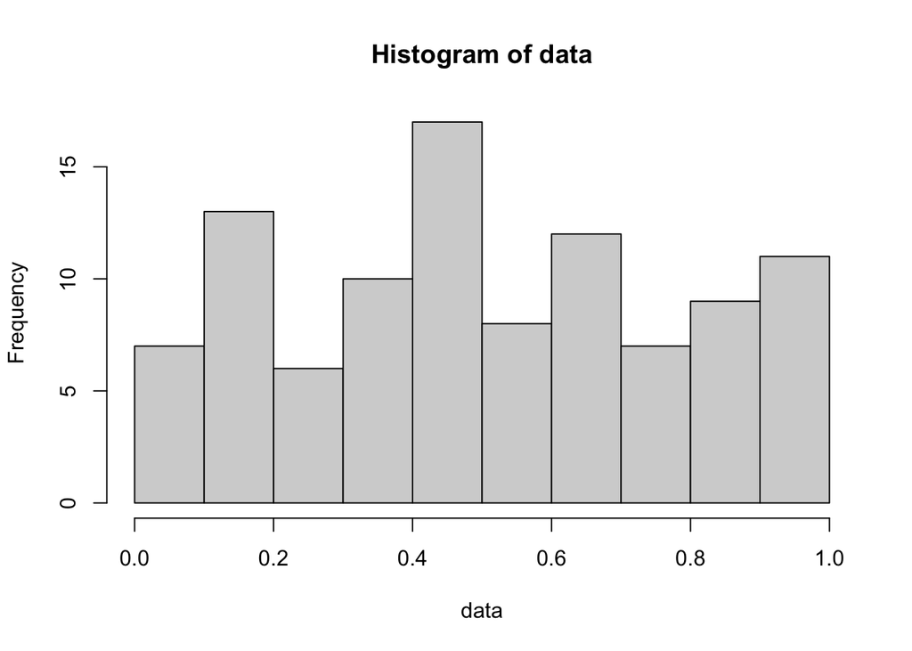

```r
data = array(dim=c(100))
i=1
while(i <= 100){
  data[i] = t.test(X[,i],mu=0)$p.value
  i = i+1
}
hist(data)
```

2. If we control Type I error for each null hypothesis at level $\alpha=$ $0.05$, then how many null hypotheses do we reject?

```r
i = 1
count = 0
while(i <= 100){
  if (data[i] < 0.05 || data[i] > .95){
    count = count + 1
  }
  i = i + 1
}
count
```

```
## [1] 10
```

3. If we control the FWER at level $0.05$, then how many null hypotheses do we reject?

```r
m = 100
alpha = 0.05
data = sort(data)
alpha.m = array(dim = c(100))
i = 1
index = 100
while(i <= 100){
  alpha.m[i] = alpha/(100-i+1)
  if(data[i]>=alpha.m){
    index = i
    break
  }
  i = i + 1
}
data
```

```
##   [1] 0.003416801 0.019047319 0.031662115 0.039615323 0.068169158 0.083883369 0.097455241 0.103764033 0.111135543 0.119193336 0.131297765
##  [12] 0.143555064 0.143878636 0.146702039 0.162132341 0.174221927 0.178321837 0.182666264 0.188391922 0.192212640 0.214856528 0.231397143
##  [23] 0.246284012 0.261434900 0.263499480 0.292217399 0.301320876 0.307861529 0.326431080 0.341655643 0.345031263 0.346321238 0.356610236
##  [34] 0.358391513 0.362535232 0.363232137 0.404487497 0.412390926 0.426316016 0.430478663 0.447578293 0.447638804 0.452751229 0.454269549
##  [45] 0.457343282 0.464995381 0.474285925 0.478843433 0.482293205 0.494391226 0.496135148 0.499826768 0.499871449 0.508167792 0.508199618
##  [56] 0.518346007 0.526689709 0.539314893 0.554233920 0.563124047 0.570283957 0.607984813 0.615148741 0.624853569 0.649047117 0.650766157
##  [67] 0.651883827 0.653122901 0.653127725 0.669743619 0.672274050 0.680379421 0.695322778 0.704709573 0.704755674 0.731917922 0.748234838
##  [78] 0.770718901 0.776060777 0.795002759 0.807785219 0.808860751 0.810260302 0.822641704 0.848462192 0.848546280 0.856709050 0.870007625
##  [89] 0.871465529 0.910681696 0.918164447 0.931700282 0.932635604 0.938401188 0.950725101 0.960827746 0.973850390 0.974839707 0.992870427
## [100] 0.999701490
```

```r
alpha.m
```

```
##   [1] 5e-04    NA    NA    NA    NA    NA    NA    NA    NA    NA    NA    NA    NA    NA    NA    NA    NA    NA    NA    NA    NA    NA
##  [23]    NA    NA    NA    NA    NA    NA    NA    NA    NA    NA    NA    NA    NA    NA    NA    NA    NA    NA    NA    NA    NA    NA
##  [45]    NA    NA    NA    NA    NA    NA    NA    NA    NA    NA    NA    NA    NA    NA    NA    NA    NA    NA    NA    NA    NA    NA
##  [67]    NA    NA    NA    NA    NA    NA    NA    NA    NA    NA    NA    NA    NA    NA    NA    NA    NA    NA    NA    NA    NA    NA
##  [89]    NA    NA    NA    NA    NA    NA    NA    NA    NA    NA    NA    NA
```

```r
index
```

```
## [1] 1
```

4. Now suppose we “cherry-pick” the 10 fund managers who perform the best in our data. If we control the FWER for just these 10 fund managers at level $0.05$, then how many null hypotheses do we reject?

```r
i = 1
averages = array(dim=c(100))
while(i<=100){
  averages[i] = mean(X[,i])
  i = i + 1
}
averages = sort(averages)
vala = array(dim=c(10))
i=1
j=1
while(i<= 100){
  if(mean(X[,i]) >= averages[90]){
    vala[j] = t.test(X[,i],mu = 0)$p.value
    j = i +1
  }
  i = i + 1
}
vala = sort(vala)
alpha = 0.05
i = 1
index = 10
while(i<=10){
  alpha.m = alpha/(10-i+1)
  if (vala[i] >= alpha.m){
    index = i
    break
  }
  i = i + 1
}
index
```

```
## [1] 2
```

(((e. **(OPTIONAL):** Read the FDR section at the end of the multiple comparison notes. Repeat part d. above but controlling for FDR at $0.05$ instead.)))